```python
# Packages imports

# Import global libraries

import warnings
import numpy as np
import pandas as pd
import seaborn  as sns
import matplotlib.pyplot as plt

# Import specific libraries

from sklearn.preprocessing import OneHotEncoder, StandardScaler, MinMaxScaler
from gower import gower_matrix
from sklearn.metrics import silhouette_samples, silhouette_score
from sklearn.cluster import KMeans, MeanShift
from kmodes.kmodes import KModes
from kmodes.kprototypes import KPrototypes
from sklearn_extra.cluster import KMedoids
from sklearn.manifold import TSNE
from sklearn.decomposition import PCA
from scipy.cluster.hierarchy import dendrogram, linkage, fcluster


# ignore warnings
warnings.filterwarnings('ignore')
```

### Repositorio: https://github.com/DemetrioMunoz/GitR.git

# Análisis exploratorio y preprocesamiento

El siguiente proyecto analizará varias técnicas de agrupamiento no supervisado para agrupar de forma significativa datos de mamografías con el objetivo de determinar el mejor modelo que diferencie entre características relacionadas con afecciones de carácter maligno.

Se utilizará la base de datos “[mammographic_masses.csv](https://data.world/julio/mammographic-masses)”. Este conjunto de datos provenine de imágenes de mamografías extraído del estudio de [Elter et al. (2007)](https://aapm.onlinelibrary.wiley.com/doi/full/10.1118/1.2786864?casa_token=-mjOYWAq-H8AAAAA%3AyXs4iOoZLGxNUXKnOsSwv65xS2HCWH91QiTLx2uA4CmzuJLASSZbhx-4XE2SUplVWbPkoNTxBpAMwXmnzA).

```python
# Read data into dataframe
data = "C:/Users/Deme/Desktop/Master/TFM/Code/GitR/mammographic_masses_data.csv"
df = pd.read_csv(data)
```

El conjunto de datos consta de 961 observaciones con 6 atributos, incluyendo la evaluación BI-RADS, la edad del paciente, la forma de la masa, el margen, la densidad y la gravedad (benigna o maligna):

| Attribute | Description | Data Type |
| --- | --- | --- |
| BI-RADS assessment | 0 to 6 (ordinal) | Ordinal |
| Age | patient's age in years | Continuous |
| Shape | Mass shape, categorical | Categorical |
|  | round | 1 |
|  | oval | 2 |
|  | lobular | 3 |
|  | irregular | 4 |
| Margin | mass margin | Categorical |
|  | circumscribed | 1 |
|  | microlobulated | 2 |
|  | obscured | 3 |
|  | ill-defined | 4 |
|  | spiculated | 5 |
| Density | mass density | Ordinal |
|  | high | 1 |
|  | iso | 2 |
|  | low | 3 |
|  | fat-containing | 4 |
| Severity | benign or malignant | Binomial |
|  | benign | 0 |
|  | malignant | 1 |

En un primer vistazo al conjunto de datos observamos valores faltantes (NaN), esto valores se eliminarán antes de procesar y transformar los datos.

```python
# Display entries of the dataset
print(df)
```

```
     score   age  shape  margin  density  malignant
0      0.0  45.0    2.0     4.0      3.0      False
1      0.0  69.0    4.0     5.0      3.0       True
2      0.0  58.0    4.0     4.0      3.0      False
3      0.0  72.0    4.0     3.0      3.0       True
4      0.0  71.0    4.0     4.0      3.0       True
..     ...   ...    ...     ...      ...        ...
956    6.0  71.0    4.0     4.0      3.0       True
957    6.0  68.0    4.0     3.0      3.0       True
958    6.0  72.0    4.0     3.0      3.0       True
959    6.0  40.0    NaN     3.0      4.0       True
960    NaN  66.0    NaN     NaN      1.0       True

[961 rows x 6 columns]
```

```python
# Count NaN in our data
print("Dataframe before removing NaN values:")
print(df.shape)
print("NaN counts in each column:")
print(df.isna().sum())

# Remove rows with NaN

df = df.dropna()
print("Dataframe after removing NaN values:")
print(df.shape)
print(df.isna().sum())
```

```
Dataframe before removing NaN values:
(961, 6)
NaN counts in each column:
score         2
age           5
shape        31
margin       48
density      76
malignant     0
dtype: int64
Dataframe after removing NaN values:
(830, 6)
score        0
age          0
shape        0
margin       0
density      0
malignant    0
dtype: int64
```

Una vez eliminados los valores faltantes, contamos cuántas observaciones son de carácter maligno y benigno.

```python
# Count malignant and benign rows
df['malignant'].value_counts()
```

```
malignant
False    427
True     403
Name: count, dtype: int64
```

Observamos que las variables tienen diferentes escalas. La variable edad es continua, mientras que las demás son variables categóricas.

Representamos cómo se distribuye la asignación BI-RADS según la edad.

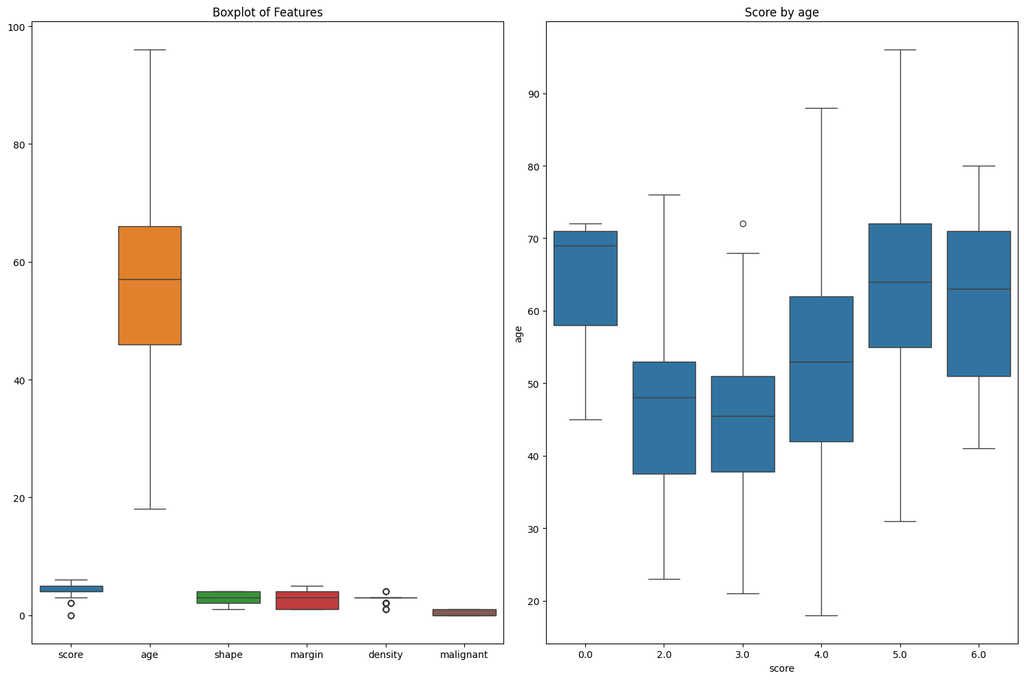

```python
# Create a figure with two subplots
fig, (ax1, ax2) = plt.subplots(1, 2, figsize=(15, 10))

# Boxplot of the features
sns.boxplot(data=df, ax=ax1)
ax1.set_title('Boxplot of Features')

# Create a scatter plot
sns.boxplot(x='score', y='age', data=df, ax=ax2)
ax2.set_title('Score by age')

# Show the plot
plt.tight_layout()
plt.show()
```

Del conjunto de datos se ha eliminado la variable de evaluación BI-RADS, ya que se trata de una variable objetivo. Es decir, con este proyecto se busca una agrupación parecida a esta variable, pero por medios computacionales. La evaluación BI-RADS ([Orel et al., 1999](https://pubs.rsna.org/doi/abs/10.1148/radiology.211.3.r99jn31845)) es una medida estandarizada para evaluar la probabilidad de malignidad de una lesión o tumor en el pecho. Esta evaluación se determina a través de la opinión del especialista luego de analizar las imágenes de las mamografías (entre otras técnicas) para comunicar los resultados de manera sencilla al paciente y a otros profesionales. El conjunto de datos utilizado solo contiene valores BI-RADS del 0 al 6 (la categoría 1 no está presente en el conjunto de datos).

| BI-RADS Category | Description |
| --- | --- |
| 0 | Incomplete (technical issues or incomplete information) |
| 1 | Normal (no abnormalities detected) |
| 2 | Benign (non-cancerous) |
| 3 | Probably benign (but may still be cancerous) |
| 4 | Suspicious (may be cancerous) |
| 5 | Highly suggestive of malignancy (highly likely to be cancerous) |
| 6 | Known biopsy-proven malignancy (confirmed cancer) |
| 7 | Known benign biopsy (confirmed non-cancerous) |

Se ha eliminado de los análisis de agrupamiento la variable "malignant". Esta variable diagnóstica se utilizará para evaluar la precisión de los grupos resultantes de los modelos.

Con las variables restantes ('age', 'shape', 'margin' y 'density') se realizarán los análisis de agrupamiento no supervisado.

```python
# Store the variables 'malignant' to evaluate the model performance at a later time
malignant_diagnosis = df['malignant']

# Select data to clustering
cluster_cols = ['age', 'shape', 'margin', 'density']
df_models = df[cluster_cols]
print(df_models)

# Convert to categorical variables
df_models['shape'] = df_models['shape'].astype('category')
df_models['margin'] = df_models['margin'].astype('category')
df_models['density'] = df_models['density'].astype('category')

df_models.info()
```

```
      age  shape  margin  density
0    45.0    2.0     4.0      3.0
1    69.0    4.0     5.0      3.0
2    58.0    4.0     4.0      3.0
3    72.0    4.0     3.0      3.0
4    71.0    4.0     4.0      3.0
..    ...    ...     ...      ...
954  80.0    4.0     5.0      3.0
955  51.0    4.0     4.0      3.0
956  71.0    4.0     4.0      3.0
957  68.0    4.0     3.0      3.0
958  72.0    4.0     3.0      3.0

[830 rows x 4 columns]
<class 'pandas.core.frame.DataFrame'>
Index: 830 entries, 0 to 958
Data columns (total 4 columns):
 #   Column   Non-Null Count  Dtype
---  ------   --------------  -----
 0   age      830 non-null    float64
 1   shape    830 non-null    category
 2   margin   830 non-null    category
 3   density  830 non-null    category
dtypes: category(3), float64(1)
memory usage: 16.0 KB
```

Una vez establecidas las variables con las que implementaremos los algoritmos de clustering, realizamos la codificación One-Hot encoding para codificar las variables categóricas a una representación numérica. También normalizaremos las variables continuas.

```python
# Select continuous and cotegorical variables
continous_variable = df_models.select_dtypes(include=['float', 'int'])
categorical_variables = df_models.select_dtypes(include=['object', 'category'])

# One-hot encode categorical variables
ohe = OneHotEncoder(sparse_output = False)

ecoder_categorical = ohe.fit_transform(categorical_variables)
categorical_encoded = pd.DataFrame(ecoder_categorical, columns=ohe.get_feature_names_out(categorical_variables.columns))

# Normalize the continuous variable (Age)
scaler = MinMaxScaler()
continous_variable_normalized = pd.DataFrame(scaler.fit_transform(continous_variable))

# Concatenate the encoded and normalized variables
df_to_gower = pd.concat([categorical_encoded, continous_variable_normalized], axis=1)
df_to_gower
```

[output not shown]

Para implementar el algoritmo K-modes, se va a realizar la discretización de la variable continua a grupos de edad en rangos de 10 años. Se cambian los valores numéricos de las etiquetas de las variables categóricas con sus correspondientes características originales.

```python
# Copy the original df to apply the transformations on a new dataset
df_kmodes = df_models.copy()
df_kmodes = df_kmodes.astype('float64')

# Replace the numerical values to their original labels
shape_mapping = {1: 'round', 2: 'oval', 3: 'lobular', 4: 'irregular'}
margin_mapping = {1: 'circumscribed', 2: 'microlobulated', 3: 'obscured', 4: 'ill-defined', 5: 'spiculated'}
density_mapping = {1: 'high', 2: 'iso', 3: 'low', 4: 'fat-containing'}

df_kmodes['age'] = df_kmodes['age'].astype(int)
df_kmodes['shape'] = df_kmodes['shape'].map(shape_mapping)
df_kmodes['margin'] = df_kmodes['margin'].map(margin_mapping)
df_kmodes['density'] = df_kmodes['density'].map(density_mapping)

# Discretize the age variable into groups of 10 years
bins = [18, 20, 30, 40, 50, 60, 70, 80, 90, 100]
labels = ['18-19', '20-29', '30-39', '40-49', '50-59', '60-69', '70-79', '80-89', '90-99']
df_kmodes['Age_group'] = pd.cut(df_kmodes['age'], bins=bins, labels=labels, right=False)
df_kmodes.drop(('age'), axis = 1, inplace = True)

# Transform all variables to categorical
df_kmodes = df_kmodes.astype('category')
df_kmodes.info()
df_kmodes
```

```
<class 'pandas.core.frame.DataFrame'>
Index: 830 entries, 0 to 958
Data columns (total 4 columns):
 #   Column     Non-Null Count  Dtype
---  ------     --------------  -----
 0   shape      830 non-null    category
 1   margin     830 non-null    category
 2   density    830 non-null    category
 3   Age_group  830 non-null    category
dtypes: category(4)
memory usage: 10.7 KB
```

|  | shape | margin | density | Age_group |
| --- | --- | --- | --- | --- |
| 0 | oval | ill-defined | low | 40-49 |
| 1 | irregular | spiculated | low | 60-69 |
| 2 | irregular | ill-defined | low | 50-59 |
| 3 | irregular | obscured | low | 70-79 |
| 4 | irregular | ill-defined | low | 70-79 |
| ... | ... | ... | ... | ... |
| 954 | irregular | spiculated | low | 80-89 |
| 955 | irregular | ill-defined | low | 50-59 |
| 956 | irregular | ill-defined | low | 70-79 |
| 957 | irregular | obscured | low | 60-69 |
| 958 | irregular | obscured | low | 70-79 |

830 rows × 4 columns

La distancia de Gower es una métrica de distancia que puede utilizarse para comparar la similitud entre dos objetos que tienen atributos tanto categóricos como continuos. Es una generalización de la distancia euclidiana que puede utilizarse con datos de tipo mixto ([Gower, 1971](https://www.jstor.org/stable/2528823?origin=crossref)).

```python
# Calculate the gower matrix
gower_dist = gower_matrix(df_to_gower)
gower_dist
```

```
array([[0.        , 0.30769232, 0.15476191, ..., 0.16666667, 0.30677655,
        0.31043956],
       [0.30769232, 0.        , 0.15293041, ..., 0.14468865, 0.1437729 ,
        0.1456044 ],
       [0.15476191, 0.15293041, 0.        , ..., 0.01190476, 0.15201466,
        0.15567766],
       ...,
       [0.16666667, 0.14468865, 0.01190476, ..., 0.        , 0.1456044 ,
        0.1437729 ],
       [0.30677655, 0.1437729 , 0.15201466, ..., 0.1456044 , 0.        ,
        0.003663  ],
       [0.31043956, 0.1456044 , 0.15567766, ..., 0.1437729 , 0.003663  ,
        0.        ]], dtype=float32)
```

# MODELOS

En este apartado, se implementarán varios modelos de clustering para determinar cuál segrega mejor las características. Se utilizarán los datos transformados anteriormente: la matriz de Gower y el conjunto de datos discretizado.

Se aplicarán métricas para evaluar el número de cluster óptimo, como la gráfica del codo y de la silueta. Además, se aplicarán técnicas de reducción de dimensionalidad para representar gráficamente los datos (PCA, T-SNE).

Por último, con la variable "malignant" que hemos extraído anteriormente, se evaluará cómo los grupos resultantes por los modelos segregan las dolencias malignas y benignas.

## K-Means

Antes de implementar el algoritmo K-means, evaluamos qué número de cluster es el óptimo para nuestros datos. Para ello, utilizaremos el método del codo y de la silueta con diferentes tipos de métodos de inicialización. Se establece una semilla para la reproducibilidad de los datos.

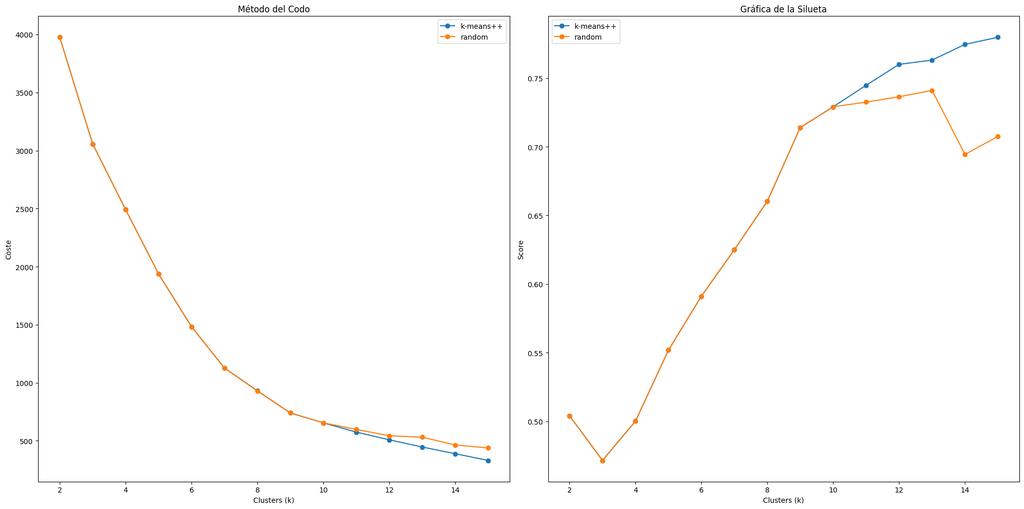

```python
# Define possible values of k and initialization methods
k_values = range(2, 16)
init_methods = ['k-means++', 'random']

# Store the inertias and silhouette scores for each combination of k and init
inertias = []
silhouette_scores = []

# Iterate over the values of k and initialization methods
for init_method in init_methods:
    inertia_values = []
    silhouette_values = []
    for k in k_values:
        kmeans = KMeans(n_clusters=k, init=init_method, n_init=100, random_state=42)
        kmeans.fit(gower_dist)
        inertia_values.append(kmeans.inertia_)
        clusters = kmeans.predict(gower_dist)
        silhouette_avg = silhouette_score(gower_dist, clusters)
        silhouette_values.append(silhouette_avg)
    inertias.append(inertia_values)
    silhouette_scores.append(silhouette_values)

# Plot the elbow curve and silhouette plot
fig, axs = plt.subplots(1, 2, figsize=(20, 10))

# Elbow plot
for i, init_method in enumerate(init_methods):
    axs[0].plot(k_values, inertias[i], marker='o', label=init_method)

axs[0].set_title('Método del Codo')
axs[0].set_xlabel('Clusters (k)')
axs[0].set_ylabel('Coste')
axs[0].legend()
axs[0].grid(False)

# Silhouette plot
for i, init_method in enumerate(init_methods):
    axs[1].plot(k_values, silhouette_scores[i], marker='o', label=init_method)

axs[1].set_title('Gráfica de la Silueta')
axs[1].set_xlabel('Clusters (k)')
axs[1].set_ylabel('Score')
axs[1].legend()
axs[1].grid(False)

plt.tight_layout()
plt.show()
```

```python
# Implement the k-means algorithm with k clusters
num_clusters =  5
kmeans = KMeans(n_clusters=num_clusters, random_state=42)
clusters_kmeans = kmeans.fit_predict(gower_dist)
```

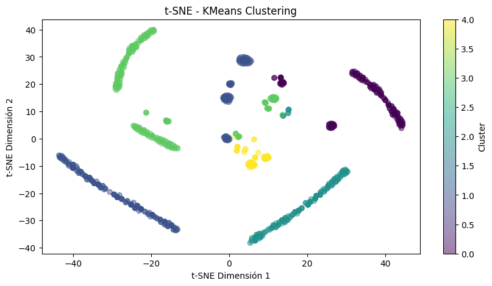

```python
# T-SNE for dimensionality reduction to 2 dimensions
tsne = TSNE(n_components=2, random_state=42)
tsne_result = tsne.fit_transform(gower_dist)

# T-SNE plot
plt.figure(figsize=(10, 5))
plt.scatter(tsne_result[:, 0], tsne_result[:, 1], c=clusters_kmeans, cmap='viridis', alpha=0.5)
plt.title('t-SNE - KMeans Clustering')
plt.xlabel('t-SNE Dimensión 1')
plt.ylabel('t-SNE Dimensión 2')
plt.colorbar(label='Cluster')
plt.grid(False)
plt.show()
```

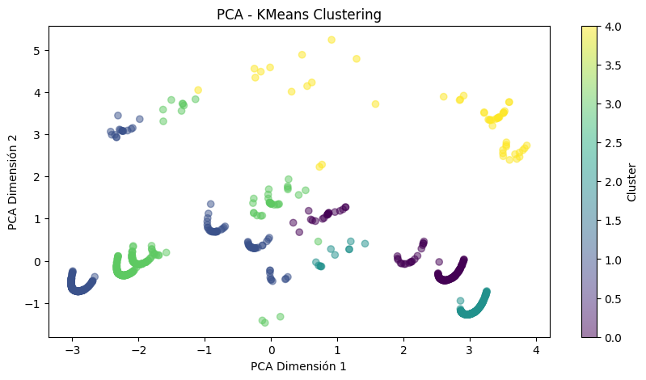

```python
# PCA for dimensionality reduction to 2 dimensions
pca = PCA(n_components=2)
pca_result = pca.fit_transform(gower_dist)

# PCA plot
plt.figure(figsize=(10, 5))
plt.scatter(pca_result[:, 0], pca_result[:, 1], c=clusters_kmeans, cmap='viridis', alpha=0.5)
plt.title('PCA - KMeans Clustering')
plt.xlabel('PCA Dimensión 1')
plt.ylabel('PCA Dimensión 2')
plt.colorbar(label='Cluster')
plt.grid(False)
plt.show()
```

```python
# Copy the df_models to eval kmeans
df_kmeans_eval = df_models.copy()

# Add cluster to dataframe
df_kmeans_eval['Cluster'] = clusters_kmeans

# Add diagnosis variable to evaluation dataframe
df_kmeans_eval['Malignant'] = malignant_diagnosis
df_kmeans_eval
```

|  | age | shape | margin | density | Cluster | Malignant |
| --- | --- | --- | --- | --- | --- | --- |
| 0 | 45.0 | 2.0 | 4.0 | 3.0 | 1 | False |
| 1 | 69.0 | 4.0 | 5.0 | 3.0 | 3 | True |
| 2 | 58.0 | 4.0 | 4.0 | 3.0 | 1 | False |
| 3 | 72.0 | 4.0 | 3.0 | 3.0 | 3 | True |
| 4 | 71.0 | 4.0 | 4.0 | 3.0 | 1 | True |
| ... | ... | ... | ... | ... | ... | ... |
| 954 | 80.0 | 4.0 | 5.0 | 3.0 | 3 | True |
| 955 | 51.0 | 4.0 | 4.0 | 3.0 | 1 | True |
| 956 | 71.0 | 4.0 | 4.0 | 3.0 | 1 | True |
| 957 | 68.0 | 4.0 | 3.0 | 3.0 | 3 | True |
| 958 | 72.0 | 4.0 | 3.0 | 3.0 | 3 | True |

830 rows × 6 columns

```python
# Count the number of malignant diagnosis by cluster
print("Malignant counts by cluster:")
print(df_kmeans_eval.groupby(['Cluster', 'Malignant']).size().unstack(fill_value=0))
```

```
Malignant counts by cluster:
Malignant  False  True
Cluster
0            123     21
1             71    176
2            143     21
3             47    177
4             43      8
```

```
Proporciones de casos malignos por cluster:
Cluster
0    0.145833
1    0.712551
2    0.128049
3    0.790179
4    0.156863
Name: Malignant, dtype: float64
```

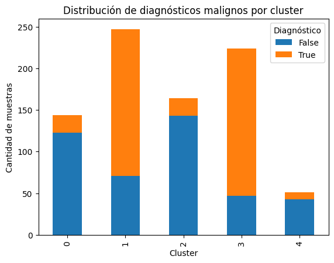

```python
# Group by cluster number and calculate the proportion of malignant cases in each cluster.
malignant_proportions = df_kmeans_eval.groupby('Cluster')['Malignant'].mean()

# Show the proportions of malignant cases by cluster.
print("Proporciones de casos malignos por cluster:")
print(malignant_proportions)

# Histogram of malignant diagnoses per cluster
plt.figure(figsize=(10, 6))
df_kmeans_eval.groupby(['Cluster', 'Malignant']).size().unstack().plot(kind='bar', stacked=True)
plt.title('Distribución de diagnósticos malignos por cluster')
plt.xlabel('Cluster')
plt.ylabel('Cantidad de muestras')
plt.legend(title='Diagnóstico')
plt.show()
```

[figure not shown]

```python
# Figures and axes for subplots
fig, axs = plt.subplots(2, 2, figsize=(15, 10))

# Plot the distribution of 'Shape' by cluster
sns.countplot(x='shape', hue='Cluster', data=df_kmeans_eval, palette='viridis', ax=axs[0, 0])
axs[0, 0].set_title('Distribución de Shape por Cluster')
axs[0, 0].set_xlabel('Shape')
axs[0, 0].set_ylabel('Número de instancias')
axs[0, 0].legend(title='Cluster')

# Plot the distribution of 'Margin' by cluster
sns.countplot(x='margin', hue='Cluster', data=df_kmeans_eval, palette='viridis', ax=axs[0, 1])
axs[0, 1].set_title('Distribución de Margin por Cluster')
axs[0, 1].set_xlabel('Margin')
axs[0, 1].set_ylabel('Número de instancias')
axs[0, 1].legend(title='Cluster')

# Plot the distribution of 'Density' by cluster
sns.countplot(x='density', hue='Cluster', data=df_kmeans_eval, palette='viridis', ax=axs[1, 0])
axs[1, 0].set_title('Distribución de Density por Cluster')
axs[1, 0].set_xlabel('Density')
axs[1, 0].set_ylabel('Número de instancias')
axs[1, 0].legend(title='Cluster')

# Plot the distribution of 'Age' by cluster
sns.countplot(x='age', hue='Cluster', data=df_kmeans_eval, palette='viridis', ax=axs[1, 1])
axs[1, 1].set_title('Distribución de Age por Cluster')
axs[1, 1].set_xlabel('Age')
axs[1, 1].set_ylabel('Número de instancias')
axs[1, 1].legend(title='Cluster')

# Adjust subplots
plt.tight_layout()

# Show plots
plt.show()
```

## K-Modes

Implementamos K-Modes con las variables categóricas y las variables continuas discretizadas.

```python
# Show dataframe for K-Modes
df_kmodes
```

|  | shape | margin | density | Age_group |
| --- | --- | --- | --- | --- |
| 0 | oval | ill-defined | low | 40-49 |
| 1 | irregular | spiculated | low | 60-69 |
| 2 | irregular | ill-defined | low | 50-59 |
| 3 | irregular | obscured | low | 70-79 |
| 4 | irregular | ill-defined | low | 70-79 |
| ... | ... | ... | ... | ... |
| 954 | irregular | spiculated | low | 80-89 |
| 955 | irregular | ill-defined | low | 50-59 |
| 956 | irregular | ill-defined | low | 70-79 |
| 957 | irregular | obscured | low | 60-69 |
| 958 | irregular | obscured | low | 70-79 |

830 rows × 4 columns

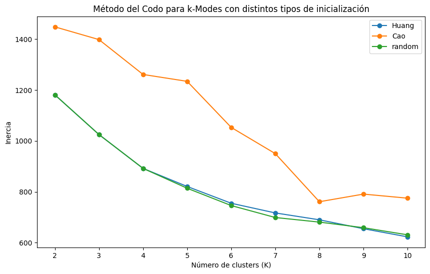

```python
# Define possible values of k and initialization methods
kmodes_values = range(2, 11)
init_methods = ['Huang', 'Cao', 'random']

inertia_values = []
for init_method in init_methods:
    inertias = []
    for k in kmodes_values:
        km = KModes(n_clusters=k, init=init_method, n_init=100, random_state=42)
        km.fit_predict(df_kmodes)
        inertias.append(km.cost_)
    inertia_values.append(inertias)

plt.figure(figsize=(10, 6))
for i, init_method in enumerate(init_methods):
    plt.plot(kmodes_values, inertia_values[i], marker='o', label=init_method)
plt.xlabel('Número de clusters (K)')
plt.ylabel('Inercia')
plt.title('Método del Codo para k-Modes con distintos tipos de inicialización')
plt.legend()
plt.grid(False)
plt.show()
```

```python
# Inicializar el modelo K-Modes con k clusters
num_clusters = 4
km = KModes(n_clusters=num_clusters, init='Huang', n_init=100, random_state=42)
clusters_kmodes = km.fit_predict(df_kmodes)
```

```python
df_kmodes_eval = df_kmodes.copy()

# Add diagnosis and Cluster variable to evaluation dataframe
df_kmodes_eval['Cluster'] = clusters_kmodes
df_kmodes_eval['Malignant'] = malignant_diagnosis
# Show dataframe
print(df_kmodes_eval)
```

```
         shape       margin density Age_group  Cluster  Malignant
0         oval  ill-defined     low     40-49        1      False
1    irregular   spiculated     low     60-69        0       True
2    irregular  ill-defined     low     50-59        0      False
3    irregular     obscured     low     70-79        0       True
4    irregular  ill-defined     low     70-79        1       True
..         ...          ...     ...       ...      ...        ...
954  irregular   spiculated     low     80-89        0       True
955  irregular  ill-defined     low     50-59        0       True
956  irregular  ill-defined     low     70-79        1       True
957  irregular     obscured     low     60-69        1       True
958  irregular     obscured     low     70-79        0       True

[830 rows x 6 columns]
```

```python
# Count the number of malignant diagnosis by cluster
print("Malignant counts by cluster:")
print(df_kmodes_eval.groupby(['Cluster', 'Malignant']).size().unstack(fill_value=0))
```

```
Malignant counts by cluster:
Malignant  False  True
Cluster
0             61    193
1             60    164
2            184     24
3            122     22
```

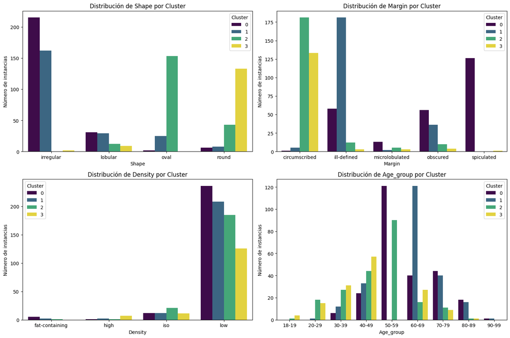

```python
# Figures and axes for subplots
fig, axs = plt.subplots(2, 2, figsize=(15, 10))

# Plot the distribution of 'Shape' by cluster
sns.countplot(x='shape', hue='Cluster', data=df_kmodes_eval, palette='viridis', ax=axs[0, 0])
axs[0, 0].set_title('Distribución de Shape por Cluster')
axs[0, 0].set_xlabel('Shape')
axs[0, 0].set_ylabel('Número de instancias')
axs[0, 0].legend(title='Cluster')

# Plot the distribution of 'Margin' by cluster
sns.countplot(x='margin', hue='Cluster', data=df_kmodes_eval, palette='viridis', ax=axs[0, 1])
axs[0, 1].set_title('Distribución de Margin por Cluster')
axs[0, 1].set_xlabel('Margin')
axs[0, 1].set_ylabel('Número de instancias')
axs[0, 1].legend(title='Cluster')

# Plot the distribution of 'Density' by cluster
sns.countplot(x='density', hue='Cluster', data=df_kmodes_eval, palette='viridis', ax=axs[1, 0])
axs[1, 0].set_title('Distribución de Density por Cluster')
axs[1, 0].set_xlabel('Density')
axs[1, 0].set_ylabel('Número de instancias')
axs[1, 0].legend(title='Cluster')

# Plot the distribution of  'Age_group' by cluster
sns.countplot(x='Age_group', hue='Cluster', data=df_kmodes_eval, palette='viridis', ax=axs[1, 1])
axs[1, 1].set_title('Distribución de Age_group por Cluster')
axs[1, 1].set_xlabel('Age_group')
axs[1, 1].set_ylabel('Número de instancias')
axs[1, 1].legend(title='Cluster')


plt.tight_layout()
plt.show()
```

```
Proporciones de casos malignos por cluster:
Cluster
0    0.759843
1    0.732143
2    0.115385
3    0.152778
Name: Malignant, dtype: float64
```

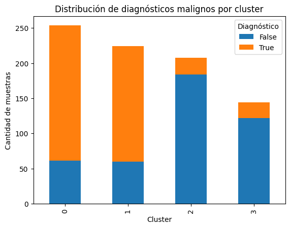

```python
# Group by cluster number and calculate the proportion of malignant cases in each cluster.
malignant_proportions = df_kmodes_eval.groupby('Cluster')['Malignant'].mean()

# Show the proportions of malignant cases by cluster.
print("Proporciones de casos malignos por cluster:")
print(malignant_proportions)

# Histogram of malignant diagnoses per cluster
plt.figure(figsize=(10, 6))
df_kmodes_eval.groupby(['Cluster', 'Malignant']).size().unstack().plot(kind='bar', stacked=True)
plt.title('Distribución de diagnósticos malignos por cluster')
plt.xlabel('Cluster')
plt.ylabel('Cantidad de muestras')
plt.legend(title='Diagnóstico')
plt.show()
```

## K-Prototypes

En este apartado vamos a aplicar el algoritmo K-prototypes que es una extensión del K-Means que permite manejar tanto datos numéricos como categóricos.

```python
df_kprototypes = df_models.copy()
print(df_kprototypes.info())

# Normalice varaible age
df_kprototypes['age_scaled'] = scaler.fit_transform(df_kprototypes[['age']])
df_kprototypes.drop(columns=['age'], inplace=True)

df_kprototypes
```

```
<class 'pandas.core.frame.DataFrame'>
Index: 830 entries, 0 to 958
Data columns (total 4 columns):
 #   Column   Non-Null Count  Dtype
---  ------   --------------  -----
 0   age      830 non-null    float64
 1   shape    830 non-null    category
 2   margin   830 non-null    category
 3   density  830 non-null    category
dtypes: category(3), float64(1)
memory usage: 16.0 KB
None
```

|  | shape | margin | density | age_scaled |
| --- | --- | --- | --- | --- |
| 0 | 2.0 | 4.0 | 3.0 | 0.346154 |
| 1 | 4.0 | 5.0 | 3.0 | 0.653846 |
| 2 | 4.0 | 4.0 | 3.0 | 0.512821 |
| 3 | 4.0 | 3.0 | 3.0 | 0.692308 |
| 4 | 4.0 | 4.0 | 3.0 | 0.679487 |
| ... | ... | ... | ... | ... |
| 954 | 4.0 | 5.0 | 3.0 | 0.794872 |
| 955 | 4.0 | 4.0 | 3.0 | 0.423077 |
| 956 | 4.0 | 4.0 | 3.0 | 0.679487 |
| 957 | 4.0 | 3.0 | 3.0 | 0.641026 |
| 958 | 4.0 | 3.0 | 3.0 | 0.692308 |

830 rows × 4 columns

```python
categorical_cols = ['shape', 'margin', 'density']
categorical_indexes = []

for c in categorical_cols:
    categorical_indexes.append(df_kprototypes.columns.get_loc(c))

categorical_indexes
```

```
[0, 1, 2]
```

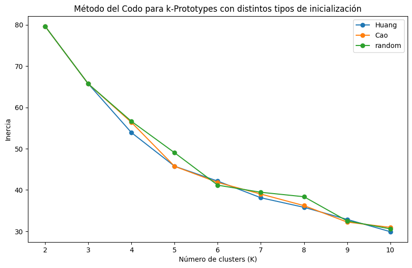

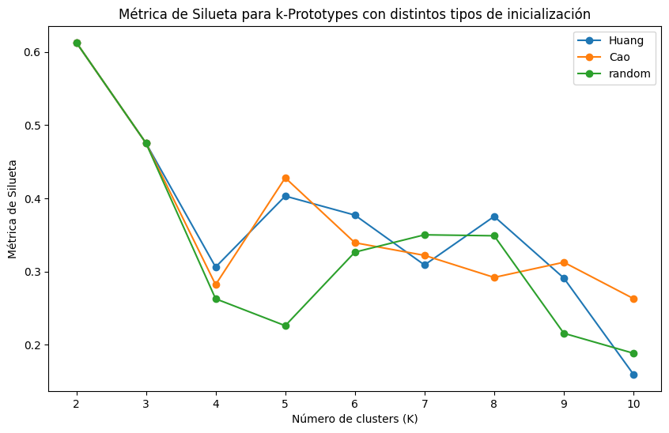

```python
# Elbow method to determine the optimal number of clusters
kprototypes_values = range(2, 11)
init_methods = ['Huang', 'Cao', 'random']
inertia_values = []

for init_method in init_methods:
    inertias = []
    for k in kprototypes_values:
        kproto = KPrototypes(n_clusters=k, init=init_method, n_init=10, random_state=42)
        kproto.fit(df_kprototypes, categorical=categorical_indexes)
        inertias.append(kproto.cost_)
    inertia_values.append(inertias)

plt.figure(figsize=(10, 6))
for i, init_method in enumerate(init_methods):
    plt.plot(kprototypes_values, inertia_values[i], marker='o', label=init_method)
plt.xlabel('Número de clusters (K)')
plt.ylabel('Inercia')
plt.title('Método del Codo para k-Prototypes con distintos tipos de inicialización')
plt.legend()
plt.grid(False)
plt.show()

# Silhouette score
silhouette_values = []

for init_method in init_methods:
    silhouettes = []
    for k in kprototypes_values:
        kproto = KPrototypes(n_clusters=k, init=init_method, n_init=10, random_state=42)
        kproto.fit(df_kprototypes, categorical=categorical_indexes)
        silhouette = silhouette_score(df_kprototypes, kproto.labels_)
        silhouettes.append(silhouette)
    silhouette_values.append(silhouettes)

plt.figure(figsize=(10, 6))
for i, init_method in enumerate(init_methods):
    plt.plot(kprototypes_values, silhouette_values[i], marker='o', label=init_method)
plt.xlabel('Número de clusters (K)')
plt.ylabel('Métrica de Silueta')
plt.title('Métrica de Silueta para k-Prototypes con distintos tipos de inicialización')
plt.legend()
plt.grid(False)
plt.show()
```

```python
# Set the number of cluster to k
kproto = KPrototypes(n_clusters = 5, init = 'Cao', n_init = 100, random_state = 42)
kproto.fit_predict(df_kprototypes, categorical = categorical_indexes)
cluster_kproto = kproto.labels_
```

```python
df_kprototypes_eval = df_kprototypes.copy()

# Add diagnosis and Cluster variable to evaluation dataframe
df_kprototypes_eval['Cluster'] = cluster_kproto
df_kprototypes_eval['Malignant'] = malignant_diagnosis

# Show dataframe
print(df_kprototypes_eval)
```

```
    shape margin density  age_scaled  Cluster  Malignant
0     2.0    4.0     3.0    0.346154        0      False
1     4.0    5.0     3.0    0.653846        2       True
2     4.0    4.0     3.0    0.512821        4      False
3     4.0    3.0     3.0    0.692308        3       True
4     4.0    4.0     3.0    0.679487        4       True
..    ...    ...     ...         ...      ...        ...
954   4.0    5.0     3.0    0.794872        2       True
955   4.0    4.0     3.0    0.423077        4       True
956   4.0    4.0     3.0    0.679487        4       True
957   4.0    3.0     3.0    0.641026        3       True
958   4.0    3.0     3.0    0.692308        3       True

[830 rows x 6 columns]
```

```python
# Count the number of malignant diagnosis by cluster
print("Malignant counts by cluster:")
print(df_kprototypes_eval.groupby(['Cluster', 'Malignant']).size().unstack(fill_value=0))
```

```
Malignant counts by cluster:
Malignant  False  True
Cluster
0            143     21
1            161     24
2             21    115
3             30     67
4             72    176
```

```
Proporciones de casos malignos por cluster:
Cluster
0    0.128049
1    0.129730
2    0.845588
3    0.690722
4    0.709677
Name: Malignant, dtype: float64
```

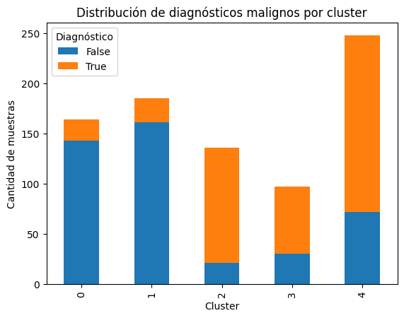

```python
# Group by cluster number and calculate the proportion of malignant cases in each cluster.
malignant_proportions = df_kprototypes_eval.groupby('Cluster')['Malignant'].mean()

# Show the proportions of malignant cases by cluster.
print("Proporciones de casos malignos por cluster:")
print(malignant_proportions)

# Histogram of malignant diagnoses per cluster
plt.figure(figsize=(10, 6))
df_kprototypes_eval.groupby(['Cluster', 'Malignant']).size().unstack().plot(kind='bar', stacked=True)
plt.title('Distribución de diagnósticos malignos por cluster')
plt.xlabel('Cluster')
plt.ylabel('Cantidad de muestras')
plt.legend(title='Diagnóstico')
plt.show()
```

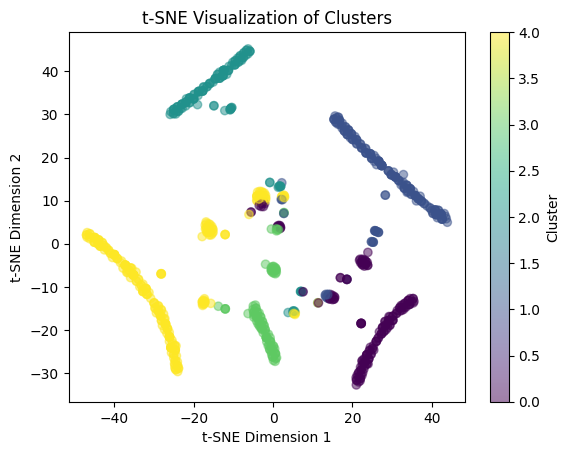

```python
# Apply t-SNE to reduce the dimensionality of the data to two dimensions
tsne = TSNE(n_components=2, random_state=42)
tsne_df = tsne.fit_transform(df_kprototypes)

# Plot the scatter plot
scatter = plt.scatter(tsne_df[:, 0], tsne_df[:, 1], c=cluster_kproto, cmap='viridis', alpha=0.5)

# Add color bar legend
plt.colorbar(scatter, label='Cluster')

# Add labels and title
plt.xlabel('t-SNE Dimension 1')
plt.ylabel('t-SNE Dimension 2')
plt.title('t-SNE Visualization of Clusters')
plt.show()
```

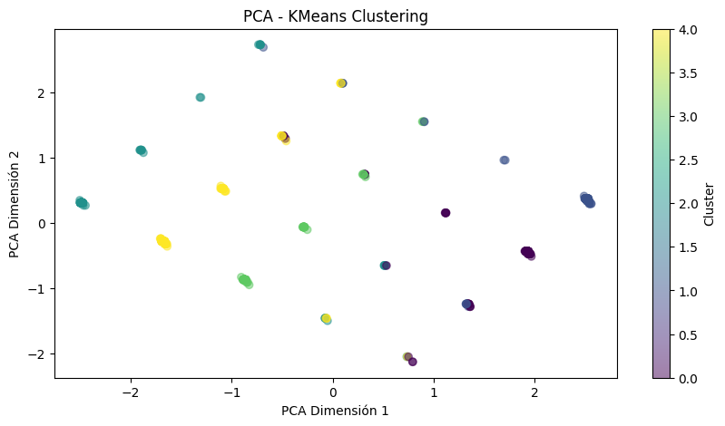

```python
# PCA for dimensionality reduction to 2 dimensions
pca = PCA(n_components=2)
pca_result = pca.fit_transform(df_kprototypes)

# PCA plot
plt.figure(figsize=(10, 5))
plt.scatter(pca_result[:, 0], pca_result[:, 1], c=cluster_kproto, cmap='viridis', alpha=0.5)
plt.title('PCA - KMeans Clustering')
plt.xlabel('PCA Dimensión 1')
plt.ylabel('PCA Dimensión 2')
plt.colorbar(label='Cluster')
plt.grid(False)
plt.show()
```

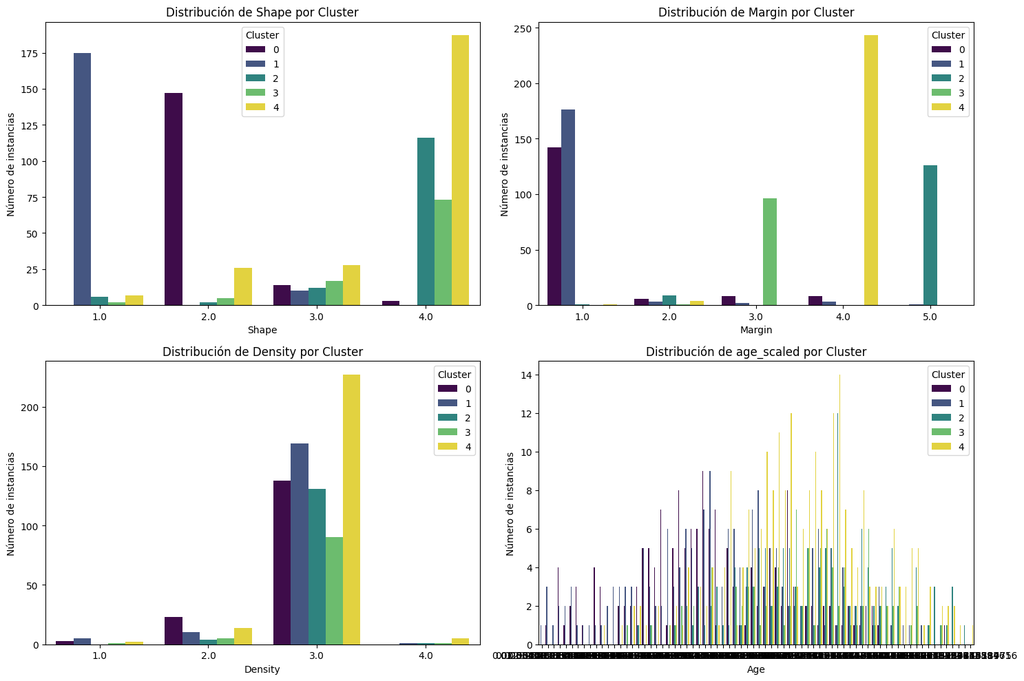

```python
# Figures and axes for subplots
fig, axs = plt.subplots(2, 2, figsize=(15, 10))

# Plot the distribution of 'Shape' by cluster
sns.countplot(x='shape', hue='Cluster', data=df_kprototypes_eval, palette='viridis', ax=axs[0, 0])
axs[0, 0].set_title('Distribución de Shape por Cluster')
axs[0, 0].set_xlabel('Shape')
axs[0, 0].set_ylabel('Número de instancias')
axs[0, 0].legend(title='Cluster')

# Plot the distribution of 'Margin' by cluster
sns.countplot(x='margin', hue='Cluster', data=df_kprototypes_eval, palette='viridis', ax=axs[0, 1])
axs[0, 1].set_title('Distribución de Margin por Cluster')
axs[0, 1].set_xlabel('Margin')
axs[0, 1].set_ylabel('Número de instancias')
axs[0, 1].legend(title='Cluster')

# Plot the distribution of 'Density' by cluster
sns.countplot(x='density', hue='Cluster', data=df_kprototypes_eval, palette='viridis', ax=axs[1, 0])
axs[1, 0].set_title('Distribución de Density por Cluster')
axs[1, 0].set_xlabel('Density')
axs[1, 0].set_ylabel('Número de instancias')
axs[1, 0].legend(title='Cluster')

# Plot the distribution of  'Agep' by cluster
sns.countplot(x='age_scaled', hue='Cluster', data=df_kprototypes_eval, palette='viridis', ax=axs[1, 1])
axs[1, 1].set_title('Distribución de age_scaled por Cluster')
axs[1, 1].set_xlabel('Age')
axs[1, 1].set_ylabel('Número de instancias')
axs[1, 1].legend(title='Cluster')

plt.tight_layout()
plt.show()
```

## K-Medoids

K-Medoids es especialmente útil cuando se tienen variables categóricas o variables que no siguen una distribución normal.

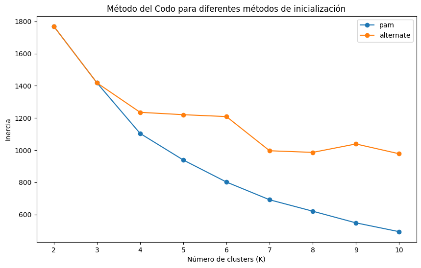

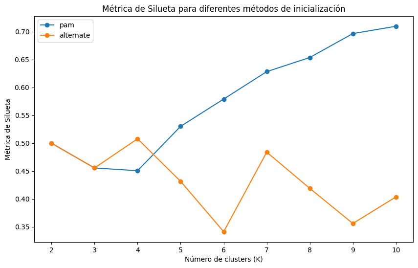

```python
# Elbow method and Silhouette plots
k_values = range(2, 11)
init_methods = ['pam', 'alternate']

inertia_values = []
silhouette_values = []

for init_method in init_methods:
    inertias = []
    silhouettes = []
    for k in k_values:
        kmedoids = KMedoids(n_clusters=k, method=init_method, random_state=42)
        kmedoids.fit(gower_dist)
        inertias.append(kmedoids.inertia_)
        silhouette = silhouette_score(gower_dist, kmedoids.labels_)
        silhouettes.append(silhouette)
    inertia_values.append(inertias)
    silhouette_values.append(silhouettes)

plt.figure(figsize=(10, 6))
for i, init_method in enumerate(init_methods):
    plt.plot(k_values, inertia_values[i], marker='o', label=init_method)
plt.xlabel('Número de clusters (K)')
plt.ylabel('Inercia')
plt.title('Método del Codo para diferentes métodos de inicialización')
plt.legend()
plt.grid(False)
plt.show()

plt.figure(figsize=(10, 6))
for i, init_method in enumerate(init_methods):
    plt.plot(k_values, silhouette_values[i], marker='o', label=init_method)
plt.xlabel('Número de clusters (K)')
plt.ylabel('Métrica de Silueta')
plt.title('Métrica de Silueta para diferentes métodos de inicialización')
plt.legend()
plt.grid(False)
plt.show()
```

```python
# K-medoids model
kmedoids = KMedoids(n_clusters=4, method = 'pam', random_state=42)
kmedoids.fit(gower_dist)
medoids_indices = kmedoids.medoid_indices_
cluster_kmedoids = kmedoids.labels_
```

```python
df_kmedoids_eval = df_models.copy()

# Add diagnosis and Cluster variable to evaluation dataframe
df_kmedoids_eval['Cluster'] = cluster_kmedoids
df_kmedoids_eval['Malignant'] = malignant_diagnosis

# Show dataframe
print(df_kmedoids_eval)
```

```
      age shape margin density  Cluster  Malignant
0    45.0   2.0    4.0     3.0        1      False
1    69.0   4.0    5.0     3.0        3       True
2    58.0   4.0    4.0     3.0        2      False
3    72.0   4.0    3.0     3.0        3       True
4    71.0   4.0    4.0     3.0        2       True
..    ...   ...    ...     ...      ...        ...
954  80.0   4.0    5.0     3.0        3       True
955  51.0   4.0    4.0     3.0        2       True
956  71.0   4.0    4.0     3.0        2       True
957  68.0   4.0    3.0     3.0        3       True
958  72.0   4.0    3.0     3.0        3       True

[830 rows x 6 columns]
```

```python
# Count the number of malignant diagnosis by cluster
print("Malignant counts by cluster:")
print(df_kmedoids_eval.groupby(['Cluster', 'Malignant']).size().unstack(fill_value=0))
```

```
Malignant counts by cluster:
Malignant  False  True
Cluster
0            156     27
1            154     27
2             70    173
3             47    176
```

```
Proporciones de casos malignos por cluster:
Cluster
0    0.147541
1    0.149171
2    0.711934
3    0.789238
Name: Malignant, dtype: float64
```

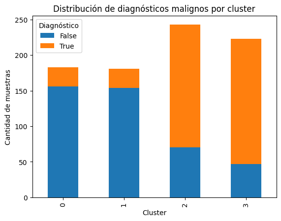

```python
# Group by cluster number and calculate the proportion of malignant cases in each cluster.
malignant_proportions = df_kmedoids_eval.groupby('Cluster')['Malignant'].mean()

# Show the proportions of malignant cases by cluster.
print("Proporciones de casos malignos por cluster:")
print(malignant_proportions)

# Histogram of malignant diagnoses per cluster
plt.figure(figsize=(10, 6))
df_kmedoids_eval.groupby(['Cluster', 'Malignant']).size().unstack().plot(kind='bar', stacked=True)
plt.title('Distribución de diagnósticos malignos por cluster')
plt.xlabel('Cluster')
plt.ylabel('Cantidad de muestras')
plt.legend(title='Diagnóstico')
plt.show()
```

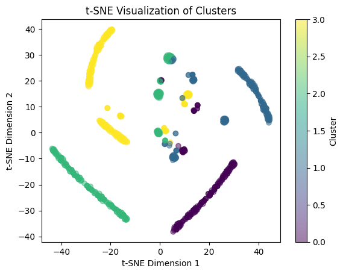

```python
# Apply t-SNE to reduce the dimensionality of the data to two dimensions
tsne = TSNE(n_components=2, random_state=42)
tsne_df = tsne.fit_transform(gower_dist)

# Plot the scatter plot
scatter = plt.scatter(tsne_df[:, 0], tsne_df[:, 1], c=cluster_kmedoids, cmap='viridis', alpha=0.5)

# Add color bar legend
plt.colorbar(scatter, label='Cluster')

# Add labels and title
plt.xlabel('t-SNE Dimension 1')
plt.ylabel('t-SNE Dimension 2')
plt.title('t-SNE Visualization of Clusters')
plt.show()
```

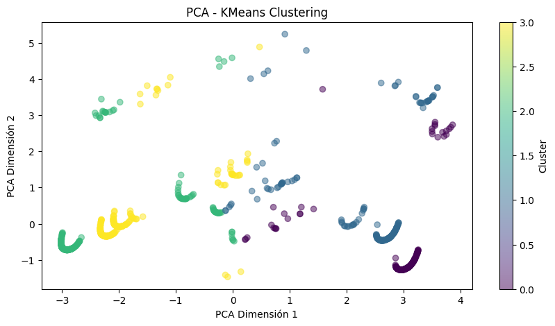

```python
# PCA for dimensionality reduction to 2 dimensions
pca = PCA(n_components=2)
pca_result = pca.fit_transform(gower_dist)

# PCA plot
plt.figure(figsize=(10, 5))
plt.scatter(pca_result[:, 0], pca_result[:, 1], c=cluster_kmedoids, cmap='viridis', alpha=0.5)
plt.title('PCA - KMeans Clustering')
plt.xlabel('PCA Dimensión 1')
plt.ylabel('PCA Dimensión 2')
plt.colorbar(label='Cluster')
plt.grid(False)
plt.show()
```

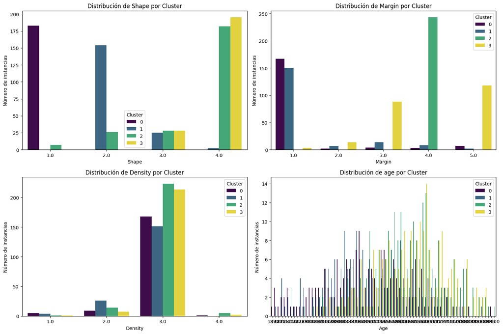

```python
# Figures and axes for subplots
fig, axs = plt.subplots(2, 2, figsize=(15, 10))

# Plot the distribution of 'Shape' by cluster
sns.countplot(x='shape', hue='Cluster', data=df_kmedoids_eval, palette='viridis', ax=axs[0, 0])
axs[0, 0].set_title('Distribución de Shape por Cluster')
axs[0, 0].set_xlabel('Shape')
axs[0, 0].set_ylabel('Número de instancias')
axs[0, 0].legend(title='Cluster')

# Plot the distribution of 'Margin' by cluster
sns.countplot(x='margin', hue='Cluster', data=df_kmedoids_eval, palette='viridis', ax=axs[0, 1])
axs[0, 1].set_title('Distribución de Margin por Cluster')
axs[0, 1].set_xlabel('Margin')
axs[0, 1].set_ylabel('Número de instancias')
axs[0, 1].legend(title='Cluster')

# Plot the distribution of 'Density' by cluster
sns.countplot(x='density', hue='Cluster', data=df_kmedoids_eval, palette='viridis', ax=axs[1, 0])
axs[1, 0].set_title('Distribución de Density por Cluster')
axs[1, 0].set_xlabel('Density')
axs[1, 0].set_ylabel('Número de instancias')
axs[1, 0].legend(title='Cluster')

# Plot the distribution of  'Agep' by cluster
sns.countplot(x='age', hue='Cluster', data=df_kmedoids_eval, palette='viridis', ax=axs[1, 1])
axs[1, 1].set_title('Distribución de age por Cluster')
axs[1, 1].set_xlabel('Age')
axs[1, 1].set_ylabel('Número de instancias')
axs[1, 1].legend(title='Cluster')

plt.tight_layout()
plt.show()
```

## Mean Shift Clustering

Mean Shift Clustering es un algoritmo de clustering no paramétrico que intenta descubrir agrupaciones en los datos encontrando y moviéndose hacia los máximos locales de una función de densidad estimada.

```python
# Adjusts the Mean Shift model
meanshift = MeanShift(bandwidth = 3)
meanshift.fit(gower_dist)

# Obtains cluster labels and centroids
cluster_msc = meanshift.labels_
centroids = meanshift.cluster_centers_

print("Etiquetas de los clusters:", cluster_msc)
```

[output not shown]

```python
df_msc_eval = df_models.copy()

# Add diagnosis and Cluster variable to evaluation dataframe
df_msc_eval['Cluster'] = cluster_msc
df_msc_eval['Malignant'] = malignant_diagnosis

# Show dataframe
print(df_msc_eval)
```

```
      age shape margin density  Cluster  Malignant
0    45.0   2.0    4.0     3.0        0      False
1    69.0   4.0    5.0     3.0        0       True
2    58.0   4.0    4.0     3.0        0      False
3    72.0   4.0    3.0     3.0        0       True
4    71.0   4.0    4.0     3.0        0       True
..    ...   ...    ...     ...      ...        ...
954  80.0   4.0    5.0     3.0        0       True
955  51.0   4.0    4.0     3.0        0       True
956  71.0   4.0    4.0     3.0        0       True
957  68.0   4.0    3.0     3.0        0       True
958  72.0   4.0    3.0     3.0        0       True

[830 rows x 6 columns]
```

```python
# Count the number of malignant diagnosis by cluster
print("Malignant counts by cluster:")
print(df_msc_eval.groupby(['Cluster', 'Malignant']).size().unstack(fill_value=0))
```

```
Malignant counts by cluster:
Malignant  False  True
Cluster
0            111    325
1            267     45
2             36      3
3             13     30
```

```
Proporciones de casos malignos por cluster:
Cluster
0    0.745413
1    0.144231
2    0.076923
3    0.697674
Name: Malignant, dtype: float64
```

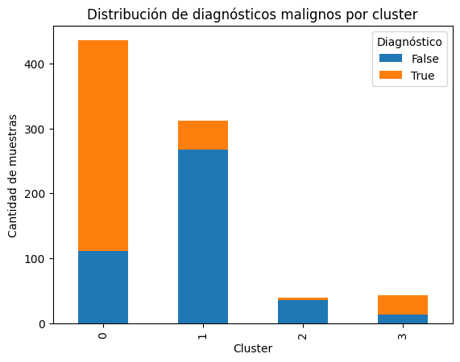

```python
# Group by cluster number and calculate the proportion of malignant cases in each cluster.
malignant_proportions = df_msc_eval.groupby('Cluster')['Malignant'].mean()

# Show the proportions of malignant cases by cluster.
print("Proporciones de casos malignos por cluster:")
print(malignant_proportions)

# Histogram of malignant diagnoses per cluster
plt.figure(figsize=(10, 6))
df_msc_eval.groupby(['Cluster', 'Malignant']).size().unstack().plot(kind='bar', stacked=True)
plt.title('Distribución de diagnósticos malignos por cluster')
plt.xlabel('Cluster')
plt.ylabel('Cantidad de muestras')
plt.legend(title='Diagnóstico')
```

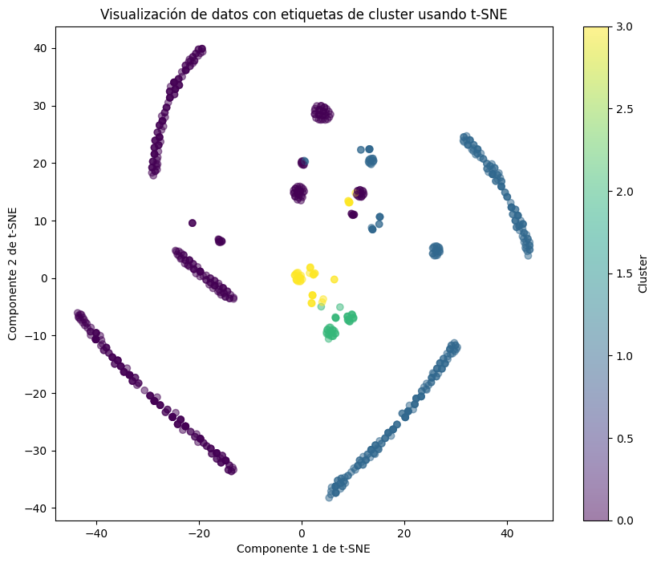

```python
tsne = TSNE(n_components=2, random_state=42)
X_tsne = tsne.fit_transform(gower_dist)

plt.figure(figsize=(10, 8))
plt.scatter(X_tsne[:, 0], X_tsne[:, 1], c=cluster_msc, cmap='viridis', alpha=0.5)
plt.title('Visualización de datos con etiquetas de cluster usando t-SNE')
plt.xlabel('Componente 1 de t-SNE')
plt.ylabel('Componente 2 de t-SNE')
plt.colorbar(label='Cluster')
plt.show()
```

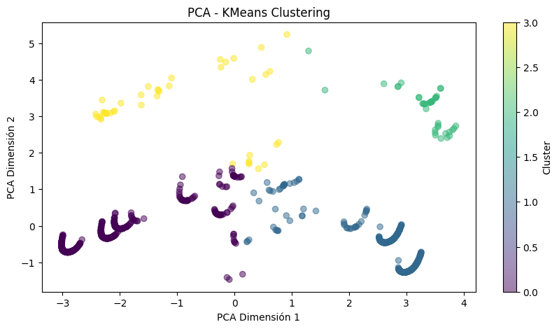

```python
# PCA for dimensionality reduction to 2 dimensions
pca = PCA(n_components=2)
pca_result = pca.fit_transform(gower_dist)

# PCA plot
plt.figure(figsize=(10, 5))
plt.scatter(pca_result[:, 0], pca_result[:, 1], c=cluster_msc, cmap='viridis', alpha=0.5)
plt.title('PCA - KMeans Clustering')
plt.xlabel('PCA Dimensión 1')
plt.ylabel('PCA Dimensión 2')
plt.colorbar(label='Cluster')
plt.grid(False)
plt.show()
```

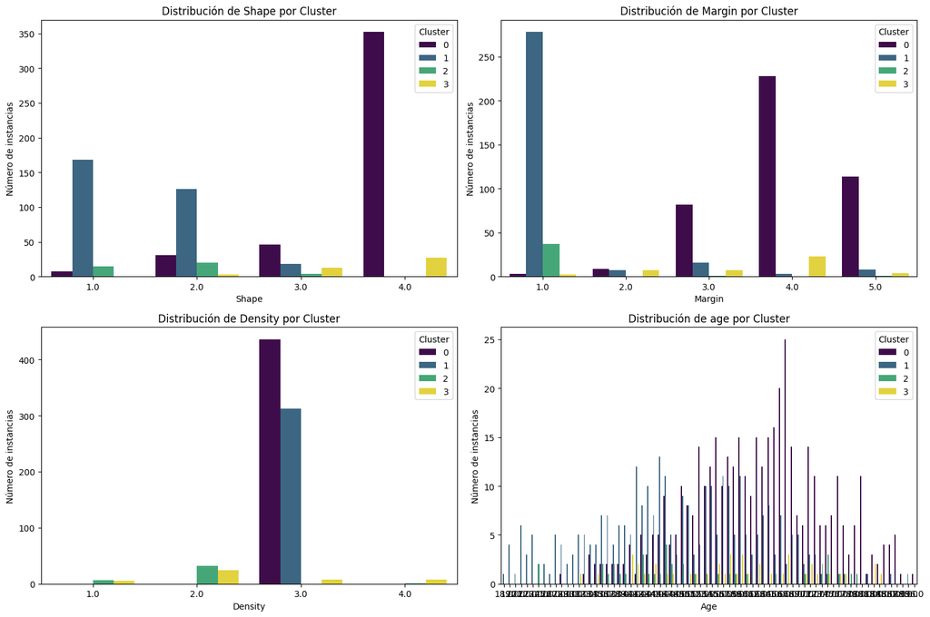

```python
# Figures and axes for subplots
fig, axs = plt.subplots(2, 2, figsize=(15, 10))

# Plot the distribution of 'Shape' by cluster
sns.countplot(x='shape', hue='Cluster', data=df_msc_eval, palette='viridis', ax=axs[0, 0])
axs[0, 0].set_title('Distribución de Shape por Cluster')
axs[0, 0].set_xlabel('Shape')
axs[0, 0].set_ylabel('Número de instancias')
axs[0, 0].legend(title='Cluster')

# Plot the distribution of 'Margin' by cluster
sns.countplot(x='margin', hue='Cluster', data=df_msc_eval, palette='viridis', ax=axs[0, 1])
axs[0, 1].set_title('Distribución de Margin por Cluster')
axs[0, 1].set_xlabel('Margin')
axs[0, 1].set_ylabel('Número de instancias')
axs[0, 1].legend(title='Cluster')

# Plot the distribution of 'Density' by cluster
sns.countplot(x='density', hue='Cluster', data=df_msc_eval, palette='viridis', ax=axs[1, 0])
axs[1, 0].set_title('Distribución de Density por Cluster')
axs[1, 0].set_xlabel('Density')
axs[1, 0].set_ylabel('Número de instancias')
axs[1, 0].legend(title='Cluster')

# Plot the distribution of  'Agep' by cluster
sns.countplot(x='age', hue='Cluster', data=df_msc_eval, palette='viridis', ax=axs[1, 1])
axs[1, 1].set_title('Distribución de age por Cluster')
axs[1, 1].set_xlabel('Age')
axs[1, 1].set_ylabel('Número de instancias')
axs[1, 1].legend(title='Cluster')

# Show plot
plt.tight_layout()
plt.show()
```

## Hierarchical Clustering

Hierarchical Clustering es un enfoque de clustering que crea una jerarquía de grupos en función de la similitud entre las observaciones. En lugar de asignar directamente las observaciones a un número fijo de clústeres como en los métodos de clustering particionales (como K-Means), el clustering jerárquico construye un árbol jerárquico de clústeres.

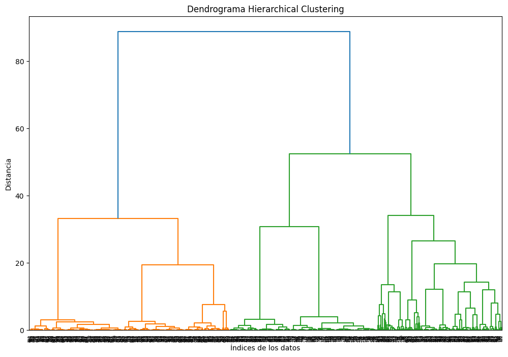

```python
# Calculate the linkage matrix using Gower's matrix
Z = linkage(gower_dist, method='ward')

# Dendogram plot
plt.figure(figsize=(12, 8))
dendrogram(Z)
plt.title('Dendrograma Hierarchical Clustering')
plt.xlabel('Índices de los datos')
plt.ylabel('Distancia')
plt.show()
```

```python
# Set a threshold to determine the number of clusters
threshold = 50

# Count the number of mergers above the threshold
num_clusters = len(Z[Z[:, 2] > threshold])

print("Número de clústeres sugerido:", num_clusters)
```

```
Número de clústeres sugerido: 2
```

```python
# Obtain cluster labels
num_clusters = 2
cluster_labels = fcluster(Z, num_clusters, criterion='maxclust')

print("Etiquetas de los clústeres:", cluster_labels)
```

[output not shown]

```python
df_eval_hc = df.copy()

# Add diagnosis and Cluster variable to evaluation dataframe
df_eval_hc['Cluster'] = cluster_labels
df_eval_hc['Malignant'] = malignant_diagnosis
df_eval_hc
```

|  | score | age | shape | margin | density | malignant | Cluster | Malignant |
| --- | --- | --- | --- | --- | --- | --- | --- | --- |
| 0 | 0.0 | 45.0 | 2.0 | 4.0 | 3.0 | False | 2 | False |
| 1 | 0.0 | 69.0 | 4.0 | 5.0 | 3.0 | True | 1 | True |
| 2 | 0.0 | 58.0 | 4.0 | 4.0 | 3.0 | False | 1 | False |
| 3 | 0.0 | 72.0 | 4.0 | 3.0 | 3.0 | True | 1 | True |
| 4 | 0.0 | 71.0 | 4.0 | 4.0 | 3.0 | True | 1 | True |
| ... | ... | ... | ... | ... | ... | ... | ... | ... |
| 954 | 6.0 | 80.0 | 4.0 | 5.0 | 3.0 | True | 1 | True |
| 955 | 6.0 | 51.0 | 4.0 | 4.0 | 3.0 | True | 1 | True |
| 956 | 6.0 | 71.0 | 4.0 | 4.0 | 3.0 | True | 1 | True |
| 957 | 6.0 | 68.0 | 4.0 | 3.0 | 3.0 | True | 1 | True |
| 958 | 6.0 | 72.0 | 4.0 | 3.0 | 3.0 | True | 1 | True |

830 rows × 8 columns

```
Proporciones de casos malignos por cluster:
Cluster
1    0.786932
2    0.263598
Name: Malignant, dtype: float64
```

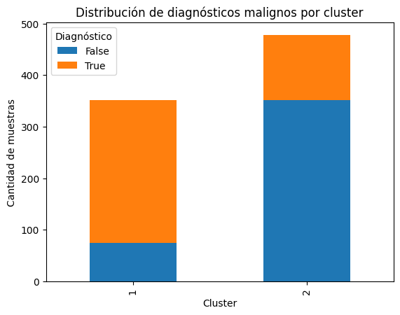

```python
# Group by cluster number and calculate the proportion of malignant cases in each cluster.
malignant_proportions = df_eval_hc.groupby('Cluster')['Malignant'].mean()

# Show the proportions of malignant cases by cluster.
print("Proporciones de casos malignos por cluster:")
print(malignant_proportions)

# Histogram of malignant diagnoses per cluster
plt.figure(figsize=(10, 6))
df_eval_hc.groupby(['Cluster', 'Malignant']).size().unstack().plot(kind='bar', stacked=True)
plt.title('Distribución de diagnósticos malignos por cluster')
plt.xlabel('Cluster')
plt.ylabel('Cantidad de muestras')
plt.legend(title='Diagnóstico')
plt.show()
```